# Heart rate and thermal exposure

Author

Alessandro Fuschi

## Setup

```r
library(tidyverse)
cfg <- list(
  data_dir = file.path("data", "5min"),
  timezone = "UTC",
  analysis_start_date = as.Date("2025-03-01"),
  steps_cutoff = 840,
  steps_bin_width = 10,
  minimum_subjects = 10
)
```

## Data import

Study window: `2025-03-01 < date < Sys.Date()` (UTC), with one row per `userId` and `bucket_5min`.

```r
if (!exists("myair_5min", inherits = FALSE)) {
  myair_5min <- read_csv(
    file.path(cfg$data_dir, "myair_5min.csv.gz"),
    col_types = cols(userId = col_character(), bucket_5min = col_datetime(), deviceId = col_character(), firmware = col_character()),
    locale = locale(tz = "UTC"), na = c("", "NA", "NULL"), show_col_types = FALSE
  )
}
air <- myair_5min
air <- air %>%
  filter(
    as.Date(bucket_5min, tz = cfg$timezone) > cfg$analysis_start_date,
    as.Date(bucket_5min, tz = cfg$timezone) < Sys.Date()
  )

if (!exists("smartwatchhigh_5min", inherits = FALSE)) {
  smartwatchhigh_5min <- read_csv(
    file.path(cfg$data_dir, "smartwatchhigh_5min.csv.gz"),
    col_types = cols(userId = col_character(), bucket_5min = col_datetime(), deviceId = col_character(), firmware = col_character()),
    locale = locale(tz = "UTC"), na = c("", "NA", "NULL"), show_col_types = FALSE
  )
}
swh <- smartwatchhigh_5min
swh <- swh %>%
  filter(
    as.Date(bucket_5min, tz = cfg$timezone) > cfg$analysis_start_date,
    as.Date(bucket_5min, tz = cfg$timezone) < Sys.Date()
  )

if (!exists("smartwatchlow_5min", inherits = FALSE)) {
  smartwatchlow_5min <- read_csv(
    file.path(cfg$data_dir, "smartwatchlow_5min.csv.gz"),
    col_types = cols(userId = col_character(), bucket_5min = col_datetime(), deviceId = col_character(), firmware = col_character()),
    locale = locale(tz = "UTC"), na = c("", "NA", "NULL"), show_col_types = FALSE
  )
}
swl <- smartwatchlow_5min
swl <- swl %>%
  filter(
    as.Date(bucket_5min, tz = cfg$timezone) > cfg$analysis_start_date,
    as.Date(bucket_5min, tz = cfg$timezone) < Sys.Date()
  )
```

## Heart-rate dataset

Heart-rate buckets are retained; activity and environment are matched by participant and bucket.

`step_mean` averages repeated minute readings; it is not their sum.

```r
hr_dat <- swh %>%
  transmute(
    userId,
    bucket_5min,
    heartrate = heartrate_mean,
    heartrate_min,
    heartrate_max
  ) %>%
  left_join(
    swl %>%
      transmute(
        userId,
        bucket_5min,
        steps = step_mean
      ),
    by = c("userId", "bucket_5min"),
    relationship = "one-to-one"
  ) %>%
  left_join(
    air %>%
      transmute(
        userId,
        bucket_5min,
        temperature = temperature_mean,
        humidity = humidity_mean
      ),
    by = c("userId", "bucket_5min"),
    relationship = "one-to-one"
  ) %>%
  arrange(userId, bucket_5min) %>%
  mutate(userId = factor(userId))
```

```r
rm(air, swh, swl)
```

## Derived variables

Humidex uses temperature and relative humidity; heart-rate range is the within-bucket maximum minus minimum.

```r
hr_dat <- hr_dat %>%
  mutate(
    humidex = ThermIndex::humidex(
      temp = temperature,
      ur = humidity
    ),
    heartrate_range = heartrate_max - heartrate_min
  )
```

## Within-subject heart rate

Heart rate is expressed in bpm relative to each participant’s mean.

```r
hr_dat <- hr_dat %>%
  group_by(userId) %>%
  mutate(
    heartrate_personal_mean = mean(heartrate, na.rm = TRUE),
    heartrate_c = heartrate - heartrate_personal_mean
  ) %>%
  ungroup()
```

## Data coverage

```r
hr_dat %>%
  summarise(
    observations = n(),
    subjects = n_distinct(userId),
    heart_rate_observations = sum(!is.na(heartrate)),
    heart_rate_with_steps = sum(!is.na(heartrate) & !is.na(steps)),
    heart_rate_with_humidex = sum(!is.na(heartrate) & !is.na(humidex))
  ) %>%
  knitr::kable(
    format = "pipe",
    col.names = c(
      "Rows",
      "Subjects",
      "Heart rate",
      "Heart rate and steps",
      "Heart rate and Humidex"
    ),
    caption = "Heart-rate dataset coverage"
  )
```

Heart-rate dataset coverage

| Rows | Subjects | Heart rate | Heart rate and steps | Heart rate and Humidex |
| --- | --- | --- | --- | --- |
| 3232678 | 203 | 3230953 | 3216977 | 878945 |

# Physical activity and heart rate

## Joint distribution

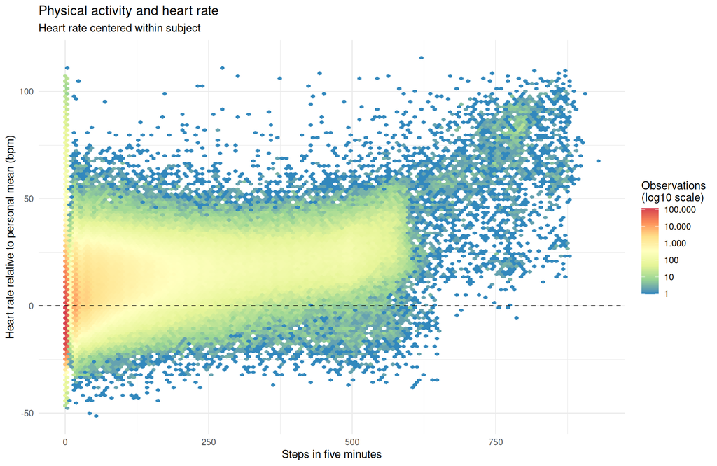

```r
hr_dat %>%
  filter(!is.na(steps), !is.na(heartrate_c)) %>%
  ggplot(aes(x = steps, y = heartrate_c)) +
  geom_hex(bins = 120) +
  geom_hline(yintercept = 0, linetype = "dashed") +
  scale_fill_distiller(
    palette = "Spectral",
    direction = -1,
    transform = "log10",
    breaks = c(1, 10, 100, 1000, 10000, 100000),
    labels = scales::label_number(
      big.mark = ".",
      decimal.mark = ","
    ),
    name = "Observations\n(log10 scale)"
  ) +
  labs(
    title = "Physical activity and heart rate",
    subtitle = "Heart rate centered within subject",
    x = "Steps in five minutes",
    y = "Heart rate relative to personal mean (bpm)"
  ) +
  theme_minimal()
```

## Heart rate by step interval

Summaries use 10-step intervals.

```r
hr_steps_summary <- hr_dat %>%
  filter(!is.na(steps), !is.na(heartrate_c)) %>%
  mutate(steps_bin = floor(steps / cfg$steps_bin_width) * cfg$steps_bin_width) %>%
  group_by(steps_bin) %>%
  summarise(
    observations = n(),
    subjects = n_distinct(userId),
    mean_heartrate_c = mean(heartrate_c),
    q25 = quantile(heartrate_c, 0.25),
    q75 = quantile(heartrate_c, 0.75),
    .groups = "drop"
  )
```

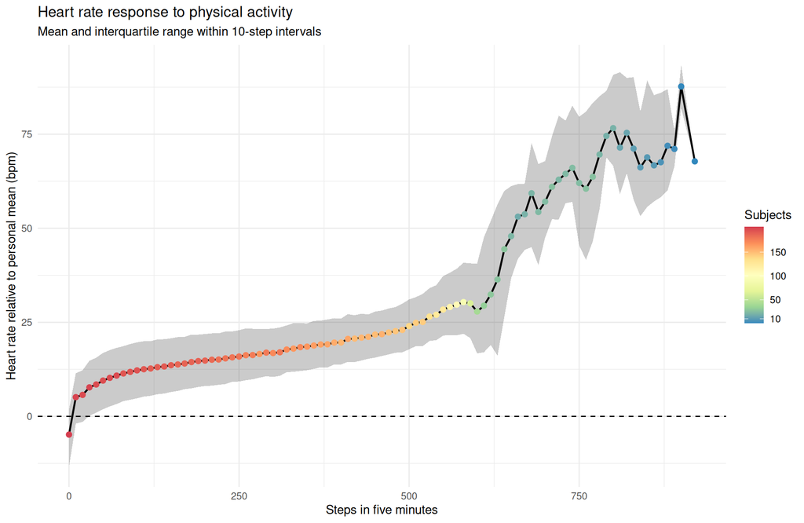

```r
hr_steps_summary %>%
  ggplot(aes(x = steps_bin, y = mean_heartrate_c)) +
  geom_ribbon(aes(ymin = q25, ymax = q75), alpha = 0.25) +
  geom_line(linewidth = 0.8) +
  geom_point(aes(color = subjects), size = 2) +
  geom_hline(yintercept = 0, linetype = "dashed") +
  scale_color_distiller(
    palette = "Spectral",
    direction = -1,
    name = "Subjects",
    breaks = c(10, 50, 100, 150)
  ) +
  labs(
    title = "Heart rate response to physical activity",
    subtitle = "Mean and interquartile range within 10-step intervals",
    x = "Steps in five minutes",
    y = "Heart rate relative to personal mean (bpm)"
  ) +
  theme_minimal()
```

## Support for high-activity intervals

```r
hr_steps_summary %>%
  filter(steps_bin >= 500) %>%
  mutate(
    mean_heartrate_c = round(mean_heartrate_c, 1),
    q25 = round(q25, 1),
    q75 = round(q75, 1)
  ) %>%
  knitr::kable(
    format = "pipe",
    col.names = c(
      "Steps",
      "Observations",
      "Subjects",
      "Mean HR",
      "Q25",
      "Q75"
    ),
    caption = "Support for high-activity intervals"
  )
```

Support for high-activity intervals

| Steps | Observations | Subjects | Mean HR | Q25 | Q75 |
| --- | --- | --- | --- | --- | --- |
| 500 | 3253 | 139 | 24.0 | 17.8 | 31.1 |
| 510 | 2716 | 144 | 24.9 | 18.7 | 31.7 |
| 520 | 2417 | 144 | 25.1 | 18.7 | 32.6 |
| 530 | 2259 | 134 | 26.5 | 20.0 | 34.1 |
| 540 | 1977 | 125 | 27.0 | 20.3 | 34.9 |
| 550 | 1845 | 126 | 28.4 | 21.5 | 37.3 |
| 560 | 1630 | 114 | 29.1 | 21.6 | 38.2 |
| 570 | 1442 | 108 | 29.7 | 21.5 | 39.2 |
| 580 | 975 | 91 | 30.4 | 22.0 | 40.8 |
| 590 | 520 | 63 | 30.0 | 20.8 | 40.7 |
| 600 | 227 | 40 | 27.9 | 16.7 | 40.6 |
| 610 | 160 | 32 | 29.4 | 17.0 | 47.6 |
| 620 | 135 | 29 | 32.4 | 19.0 | 51.9 |
| 630 | 114 | 27 | 36.4 | 16.1 | 56.4 |
| 640 | 115 | 28 | 44.4 | 26.5 | 59.9 |
| 650 | 97 | 22 | 47.9 | 36.7 | 61.2 |
| 660 | 82 | 17 | 53.1 | 41.9 | 61.8 |
| 670 | 112 | 20 | 53.7 | 44.3 | 61.8 |
| 680 | 81 | 21 | 59.3 | 45.0 | 72.7 |
| 690 | 84 | 23 | 54.3 | 40.2 | 67.1 |
| 700 | 82 | 24 | 57.1 | 47.5 | 67.9 |
| 710 | 91 | 26 | 61.0 | 52.4 | 74.4 |
| 720 | 95 | 22 | 62.9 | 52.3 | 79.9 |
| 730 | 93 | 23 | 64.5 | 56.7 | 78.6 |
| 740 | 112 | 24 | 66.0 | 57.0 | 82.6 |
| 750 | 125 | 24 | 62.0 | 45.4 | 79.6 |
| 760 | 132 | 26 | 60.5 | 41.6 | 81.0 |
| 770 | 167 | 26 | 63.7 | 46.5 | 83.3 |
| 780 | 194 | 21 | 69.6 | 55.2 | 85.1 |
| 790 | 207 | 19 | 74.5 | 68.9 | 86.5 |
| 800 | 96 | 20 | 76.6 | 66.6 | 90.8 |
| 810 | 73 | 14 | 71.4 | 59.1 | 91.5 |
| 820 | 65 | 14 | 75.4 | 64.7 | 90.0 |
| 830 | 48 | 11 | 71.2 | 57.6 | 90.2 |
| 840 | 82 | 9 | 66.2 | 53.2 | 80.9 |
| 850 | 91 | 9 | 68.8 | 55.7 | 89.3 |
| 860 | 68 | 9 | 66.7 | 57.1 | 85.4 |
| 870 | 71 | 6 | 67.5 | 58.3 | 86.0 |
| 880 | 16 | 4 | 71.9 | 60.0 | 87.0 |
| 890 | 10 | 3 | 71.1 | 66.4 | 76.0 |
| 900 | 2 | 1 | 87.7 | 81.9 | 93.4 |
| 920 | 1 | 1 | 67.8 | 67.8 | 67.8 |

Values ≥ 840 steps/5 min are excluded because of sparse upper-tail support in the earlier snapshot. This is an exploratory cutoff, not a physiological limit.

```r
hr_steps_dat <- hr_dat %>%
  filter(
    !is.na(steps),
    !is.na(heartrate_c),
    steps < cfg$steps_cutoff
  ) %>%
  droplevels()
```

# Activity-adjusted heart rate

A GAM and a cubic polynomial describe the activity–heart-rate association.

```r
hr_steps_dat <- hr_steps_dat %>%
  mutate(steps_100 = steps / 100)

hr_steps_gam <- mgcv::bam(
  heartrate_c ~ s(steps, k = 30),
  data = hr_steps_dat,
  method = "fREML",
  discrete = TRUE
)

hr_steps_cubic <- lm(
  heartrate_c ~
    steps_100 +
    I(steps_100^2) +
    I(steps_100^3),
  data = hr_steps_dat
)
```

## Model comparison

```r
gam_summary <- summary(hr_steps_gam)
cubic_summary <- summary(hr_steps_cubic)

hr_steps_model_comparison <- tibble(
  model = c(
    "GAM: s(steps, k = 30)",
    "Cubic polynomial"
  ),
  variance_explained = c(
    gam_summary$dev.expl,
    cubic_summary$adj.r.squared
  ),
  residual_sd = c(
    sqrt(gam_summary$scale),
    cubic_summary$sigma
  ),
  complexity = c(
    paste0(round(gam_summary$s.table[1, "edf"], 1), " EDF"),
    "3 polynomial terms"
  )
) %>%
  mutate(
    variance_explained = scales::percent(
      variance_explained,
      accuracy = 0.1
    ),
    residual_sd = round(residual_sd, 2)
  )

hr_steps_model_comparison %>%
  knitr::kable(
    format = "pipe",
    col.names = c(
      "Model",
      "Variance explained",
      "Residual SD",
      "Complexity"
    ),
    caption = "Physical-activity model comparison"
  )
```

Physical-activity model comparison

| Model | Variance explained | Residual SD | Complexity |
| --- | --- | --- | --- |
| GAM: s(steps, k = 30) | 31.9% | 11.26 | 28.6 EDF |
| Cubic polynomial | 29.4% | 11.47 | 3 polynomial terms |

## Fitted relationships

```r
steps_predictions <- tibble(
  steps = seq(
    min(hr_steps_dat$steps),
    max(hr_steps_dat$steps),
    length.out = 500
  )
) %>%
  mutate(steps_100 = steps / 100)

steps_predictions <- steps_predictions %>%
  mutate(
    gam = predict(
      hr_steps_gam,
      newdata = steps_predictions
    ),
    cubic = predict(
      hr_steps_cubic,
      newdata = steps_predictions
    )
  ) %>%
  pivot_longer(
    cols = c(gam, cubic),
    names_to = "model",
    values_to = "expected_heartrate"
  ) %>%
  mutate(
    model = recode(
      model,
      gam = "GAM",
      cubic = "Cubic polynomial"
    )
  )
```

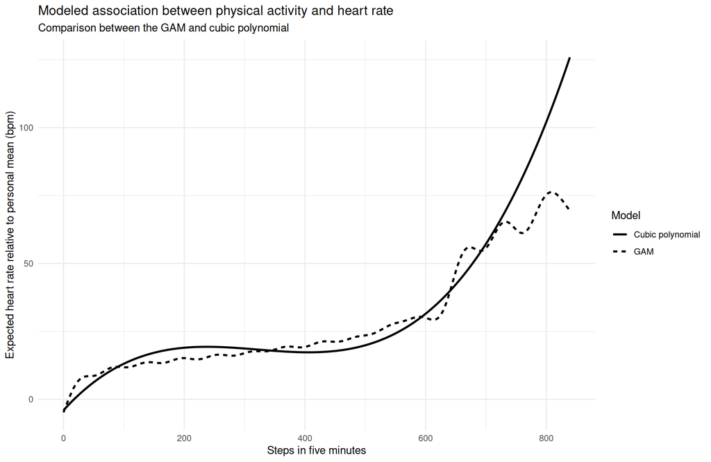

```r
steps_predictions %>%
  ggplot(
    aes(
      x = steps,
      y = expected_heartrate,
      linetype = model
    )
  ) +
  geom_line(linewidth = 1) +
  labs(
    title = "Modeled association between physical activity and heart rate",
    subtitle = "Comparison between the GAM and cubic polynomial",
    x = "Steps in five minutes",
    y = "Expected heart rate relative to personal mean (bpm)",
    linetype = "Model"
  ) +
  theme_minimal()
```

The cubic fit is retained for exploratory adjustment, not selected through independent validation. Neither model accounts for within-subject dependence.

## Activity-adjusted outcome

```r
hr_steps_dat <- hr_steps_dat %>%
  mutate(
    heartrate_activity_expected = fitted(hr_steps_cubic),
    heartrate_activity_adj = residuals(hr_steps_cubic)
  )
```

`heartrate_activity_adj` is the cubic-model residual (bpm); positive values exceed the activity-based prediction.

## Residual association with physical activity

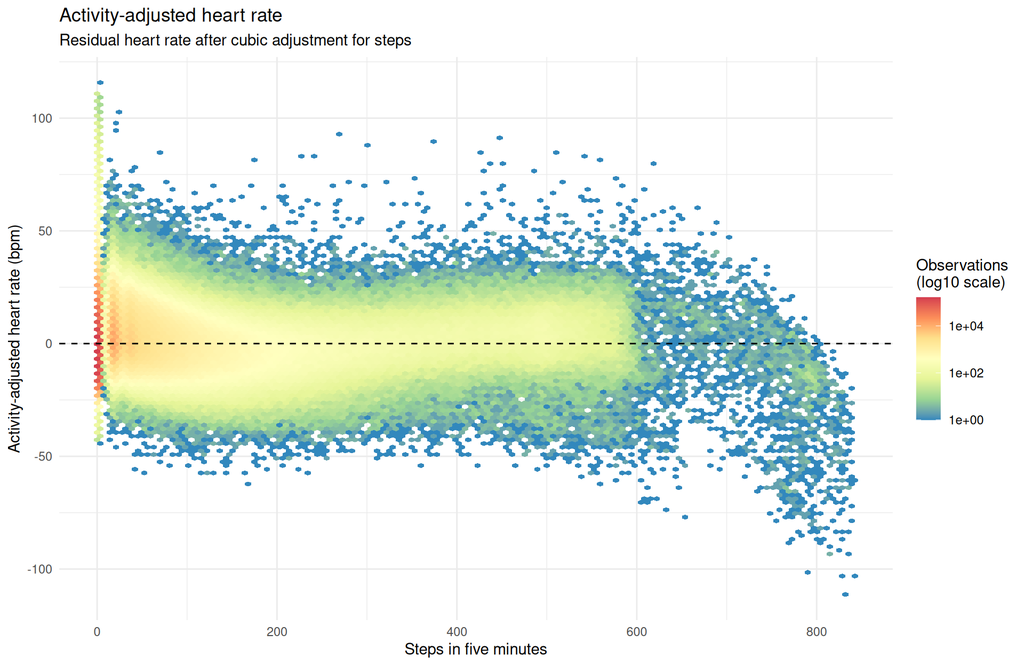

```r
hr_steps_dat %>%
  ggplot(aes(x = steps, y = heartrate_activity_adj)) +
  geom_hex(bins = 120) +
  geom_hline(yintercept = 0, linetype = "dashed") +
  scale_fill_distiller(
    palette = "Spectral",
    direction = -1,
    transform = "log10",
    name = "Observations\n(log10 scale)"
  ) +
  labs(
    title = "Activity-adjusted heart rate",
    subtitle = "Residual heart rate after cubic adjustment for steps",
    x = "Steps in five minutes",
    y = "Activity-adjusted heart rate (bpm)"
  ) +
  theme_minimal()
```

# Thermal exposure and activity-adjusted heart rate

## Humidex

Within each one-unit Humidex interval, participant means receive equal weight. Intervals require at least 10 participants to limit sparse support.

```r
hr_humidex_summary <- hr_steps_dat %>%
  filter(
    !is.na(humidex),
    !is.na(heartrate_activity_adj)
  ) %>%
  mutate(humidex_bin = floor(humidex)) %>%
  group_by(userId, humidex_bin) %>%
  summarise(
    user_mean = mean(heartrate_activity_adj),
    observations = n(),
    .groups = "drop"
  ) %>%
  group_by(humidex_bin) %>%
  summarise(
    observations = sum(observations),
    subjects = n(),
    mean_heartrate_adj = mean(user_mean),
    sd_between_subjects = sd(user_mean),
    .groups = "drop"
  ) %>%
  filter(subjects >= cfg$minimum_subjects) %>%
  mutate(
    se = sd_between_subjects / sqrt(subjects),
    ci_low =
      mean_heartrate_adj -
      qt(0.975, df = subjects - 1) * se,
    ci_high =
      mean_heartrate_adj +
      qt(0.975, df = subjects - 1) * se
  )
```

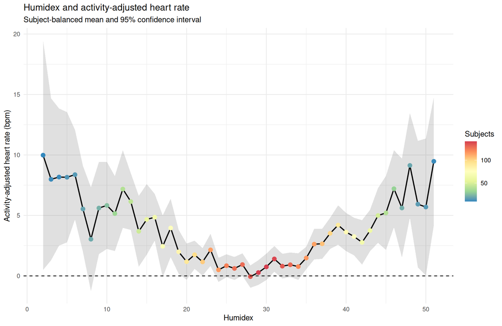

```r
hr_humidex_summary %>%
  ggplot(aes(x = humidex_bin, y = mean_heartrate_adj)) +
  geom_ribbon(
    aes(ymin = ci_low, ymax = ci_high),
    alpha = 0.15
  ) +
  geom_line(linewidth = 0.8) +
  geom_point(aes(color = subjects), size = 2.5) +
  geom_hline(yintercept = 0, linetype = "dashed") +
  scale_color_distiller(
    palette = "Spectral",
    direction = -1,
    name = "Subjects"
  ) +
  labs(
    title = "Humidex and activity-adjusted heart rate",
    subtitle = "Subject-balanced mean and 95% confidence interval",
    x = "Humidex",
    y = "Activity-adjusted heart rate (bpm)"
  ) +
  theme_minimal()
```

Formal inference requires joint modelling of activity and thermal exposure with within-subject dependence.